# BFX_GenVisR

## install GenVisR

```r
if (!requireNamespace("BiocManager", quietly = TRUE)) install.packages("BiocManager")
    BiocManager::install("GenVisR")
```

## Create basic Waterfall

1. Load the “GenVisR” and “data.table” libraries, if they are not installed (see Support Protocol 1). Note that data.table is a GenVisR dependency and will be installed automatically when installing GenVisR

```r
library(GenVisR)
library(data.table)
```

2. Read in available mutation data; here we read a custom TSV file directly from a URL into a data.table object.

```r
myVars <- fread("http://genomedata.org/gen-viz-workshop/GenVisR/BKM120_Mutation_Data.tsv")
```

3. The Waterfall() function will look for specific column names within the data.table; these are expected to be “sample”, “gene”, and “mutation”. Here we rename our columns to conform to this expectation. The amino acid change column is not required, but is used in Basic Protocol 4. All other columns are not used and ignored.

```r
myVars <- myVars[,.(`patient`, `gene name`, `trv type`, `amino acid change`)]
setnames(myVars, c("sample", "gene", "mutation", "amino acid change"))
myVars
```

```
##     sample    gene        mutation    amino acid change
##  1:      2    PTEN   splice_region                 e7-3
##  2:      2    PTEN frame_shift_ins             p.P248fs
##  3:      2  MAP3K1 frame_shift_del             p.S822fs
##  4:      2  MALAT1             rna                 NULL
##  5:      2   MED12        missense             p.S1892F
##  6:      4   RUNX1 frame_shift_ins             p.W457fs
##  7:      4  PIK3CA        missense              p.E545K
##  8:      4   FBXW7        missense              p.R465H
##  9:      4  ARID1A        missense             p.E1542K
## 10:      4   MED12        missense              p.R540C
## 11:      4    TAB1        missense               p.E50K
## 12:      5  MAP2K4        nonsense              p.W186*
## 13:      5    TBX3 splice_site_del                 e6-1
## 14:      5  PIK3CA        missense              p.E542K
```

[output cut: 62 more lines]

4. In situations where there are multiple mutations for the same gene/sample, we need to specify which mutation type should get the priority for plotting purposes. This is done by defining a mutation hierarchy as a data.table, where the most significant mutation should come first. We also tell Waterfall what colors we would like to plot in this step.

```r
myHierarchy <- data.table("mutation"=c("nonsense", "frame_shift_del", "frame_shift_ins", "in_frame_del", "splice_site_del", "splice_site", "missense", "splice_region", "rna"),
                          "color"=c("#FF0000", "#00A08A", "#F2AD00", "#F98400", "#5BBCD6", "#046C9A", "#D69C4E", "#000000", "#446455"))
myHierarchy
```

```
##           mutation   color
## 1:        nonsense #FF0000
## 2: frame_shift_del #00A08A
## 3: frame_shift_ins #F2AD00
## 4:    in_frame_del #F98400
## 5: splice_site_del #5BBCD6
## 6:     splice_site #046C9A
## 7:        missense #D69C4E
## 8:   splice_region #000000
## 9:             rna #446455
```

5. With the core data imported, we can now construct our plot object. The output will include not only graphical objects, but the underlying data from which they were constructed as well.

```r
plotData <- Waterfall(myVars, mutationHierarchy = myHierarchy)
```

```
## This function is part of the new S4 feature and is under active development, did you mean to use waterfall() with a lower case w?
```

6. Waterfall objects are S4 objects with 5 slots for grob objects and 6 slots for data, they can be accessed with the @ symbol.

```r
plotData
```

[output not shown]

[output cut: 228 more lines]

7. print a plot

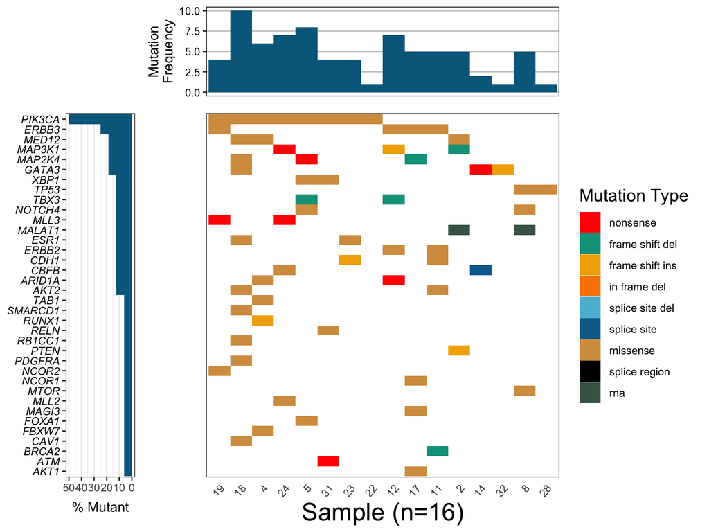

```r
drawPlot(plotData)
```

## Add clinical data to a Waterfall() plot

1. First, read the clinical data. In this case, data is saved in a custom TSV file and read directly from a URL.

```r
myClinical <- fread("http://genomedata.org/gen-viz-workshop/GenVisR/BKM120_Clinical.tsv")
```

2. Subset the clinical data to the data needed for this example. We require sample information and one or more clinical variables.

```r
myClinical <- myClinical[,.(`sample Number`, `Best response`, `PTEN Immunohist.`)]
```

3. The “sample” name column should be named as such, and should match those sample designations that were used in the myVars data structure (i.e., Sample 1 should be named as such in both the myVars and myClinical data objects).

```r
setnames(myClinical, c("sample", "Best response", "PTEN Immunohist."))
myClinical[,sample := gsub("WU0+","",sample)]
```

4. Create a named vector for clinical variables and colors to set a color palette. In our example, we have six clinical variables that we must supply names and colors for.

```r
myClinicalColors <- c("Progressive Disease"="#798E87", "Stable Disease"="#C27D38", "Partial Response"="#CCC591", "negative"="#29211F", "positive"="#9C964A", "unknown"="#85D4E3")
```

5. Read the clinical information into GenVisR via the Clinical() function. This function looks for a data.frame or data.table with a “sample” column. All other columns will be treated as clinical variables. We also set a color palette and specify that we would like our legend split up into two columns.

```r
clinicalData <- Clinical(inputData = myClinical, palette = myClinicalColors, legendColumns = 2)
```

```
## This function is currently under development
```

6. Call the Waterfall() function as before, this time including the clinical object we created above via the “clinical” parameter.

```r
plotData <- Waterfall(myVars, mutationHierarchy = myHierarchy, clinical = clinicalData)
```

```
## This function is part of the new S4 feature and is under active development, did you mean to use waterfall() with a lower case w?
```

7. view the plot

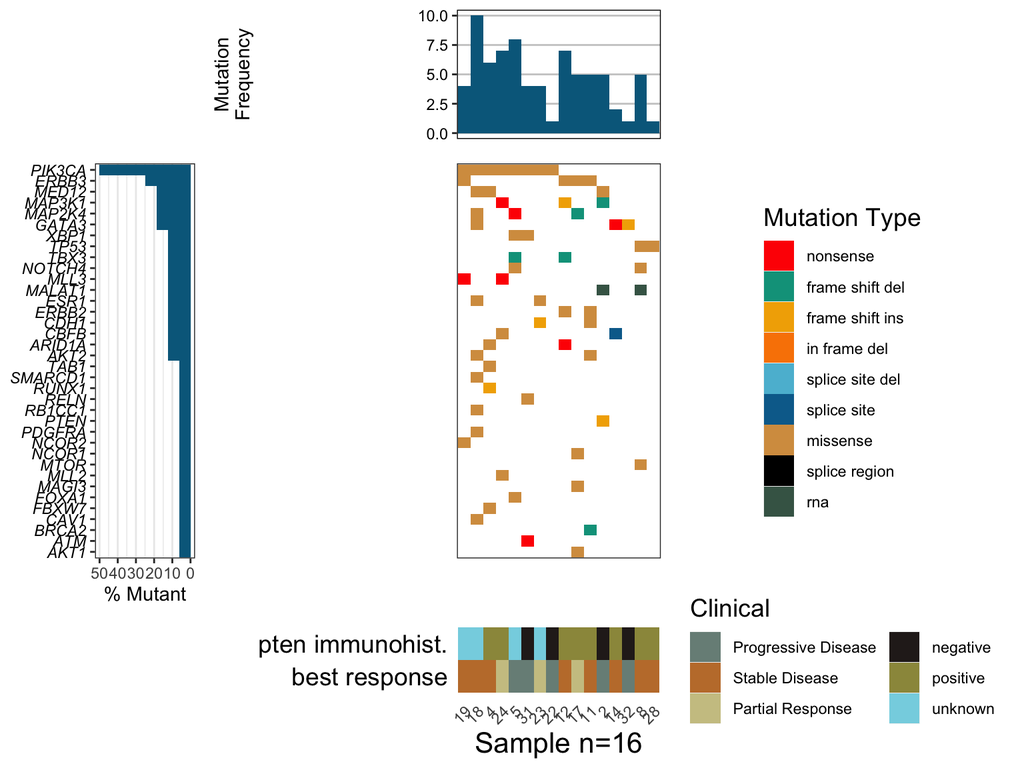

```r
drawPlot(plotData)
```

## customizing the mutation burden panel

1. First, read in the coverage data from a custom TSV file. The file contains a sample column and the number of bases covered to at least 20×.

```r
mutationBurden <- fread("http://genomedata.org/gen-viz-workshop/GenVisR/bkm120_coverage.txt")
```

2. The sample column must match the sample identifiers used in the main plot. We use a regular expression here so the identifiers match between the data in the mutationBurden and myVars objects.

```r
mutationBurden[,sample := gsub("WU0+", "", sample)]
```

3. The parameter in Waterfall() that specifies the coverage space for each sample requires a named vector. Here we create that object.

```r
myMutBurden <- as.numeric(mutationBurden$coverage)
names(myMutBurden) <- mutationBurden$sample
```

4. The Waterfall() function will plot mutation burden instead of mutation frequency if we set the “burden” flag for the “plotA” parameter. We also supply the named vector holding the coverage space so Waterfall() can properly calculate this for each sample using the parameter “coverage”.

```r
plotData <- Waterfall(myVars, mutationHierarchy = myHierarchy, coverage=myMutBurden, plotA = "burden")
```

```
## This function is part of the new S4 feature and is under active development, did you mean to use waterfall() with a lower case w?
```

5. draw the plot

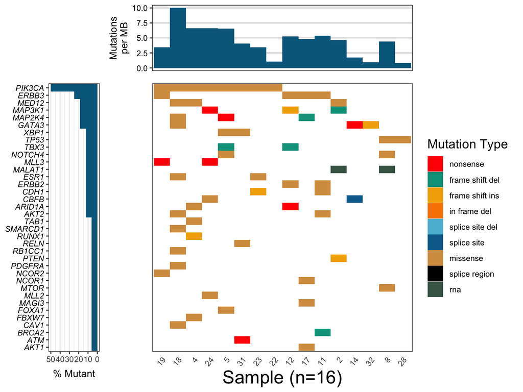

```r
drawPlot(plotData)
```

## Exploration of custom Waterfall() options

1. The waterfall function can tabulate counts per mutation type for both the sample and gene subplots; these are controlled by switching the plotATally and plotBTally parameters to from “simple” to “complex”. With these parameter settings, the top and side plots now show a more complex view of mutation frequency colored by mutation type.

```r
plotData <- Waterfall(myVars, mutationHierarchy = myHierarchy, plotATally = "complex", plotBTally = "complex")
```

```
## This function is part of the new S4 feature and is under active development, did you mean to use waterfall() with a lower case w?
```

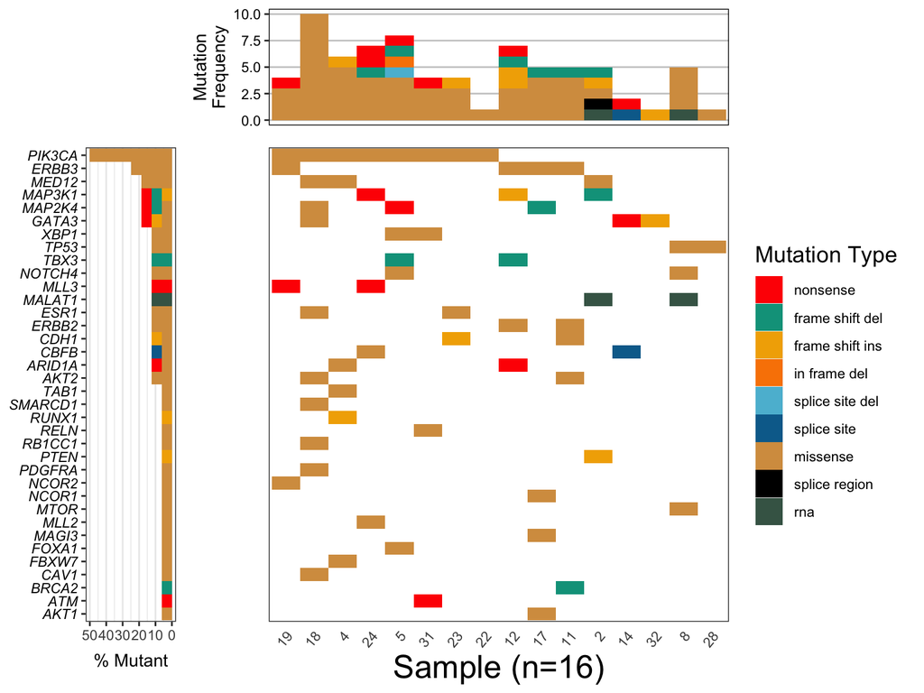

```r
drawPlot(plotData)
```

2. A common request is to add additional information to waterfall plot cells in addition to mutation type. GenVisR supports this if there is a column in the original input from which to pull additional annotations. Here we modify the labels in the “amino acid change” column of myVars (see Basic Protocol 1), and set up Waterfall() to pull these annotations.

```r
myVars[,`amino acid change` := gsub("p.", "", `amino acid change`)]
plotData <- Waterfall(myVars, labelColumn="amino acid change", mutationHierarchy = myHierarchy, plotATally = "complex", plotBTally = "complex")
```

```
## This function is part of the new S4 feature and is under active development, did you mean to use waterfall() with a lower case w?
```

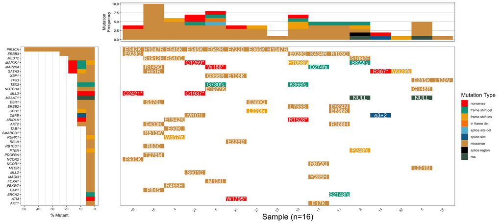

```r
drawPlot(plotData)
```

3. It is often useful to view only a subset of available data. Here, we will use the geneMax parameter to specify that only the top 10 most common genes should be displayed.

```r
plotData <- Waterfall(myVars, labelColumn="amino acid change", mutationHierarchy = myHierarchy, plotATally = "complex", plotBTally = "complex", geneMax=10)
```

```
## This function is part of the new S4 feature and is under active development, did you mean to use waterfall() with a lower case w?
```

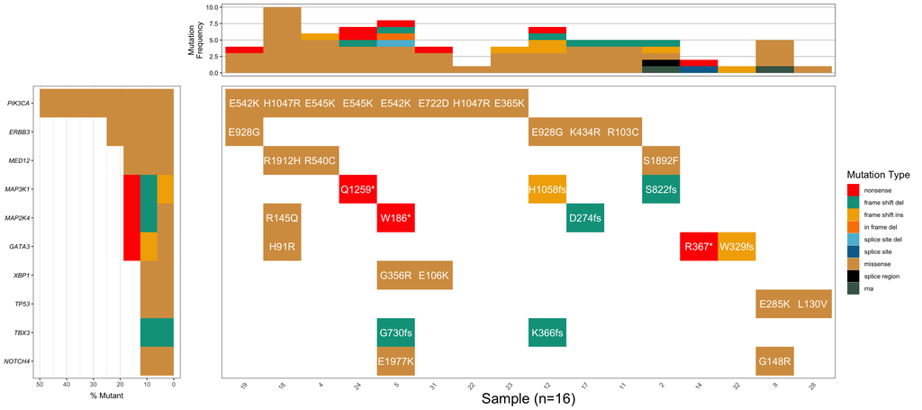

```r
drawPlot(plotData)
```

4. Adding ggplot2 layers to a plot allows control over aesthetic elements. Here we adjust the axis text of the main plot to be horizontal, bigger, and colored red. We load the ggplot2 library first, then use ggplot2 syntax and save the resulting object into a list. This is then passed into the Waterfall() function via the parameter “plotCLayers”.

```r
library(ggplot2)
newLayer <- list(theme(axis.text.x=element_text(angle=0, color="tomato1", size=16)))
plotData <- Waterfall(myVars, labelColumn="amino acid change", mutationHierarchy = myHierarchy, plotATally = "complex", plotBTally = "complex", geneMax=10, plotCLayers = newLayer)
```

```
## This function is part of the new S4 feature and is under active development, did you mean to use waterfall() with a lower case w?
```

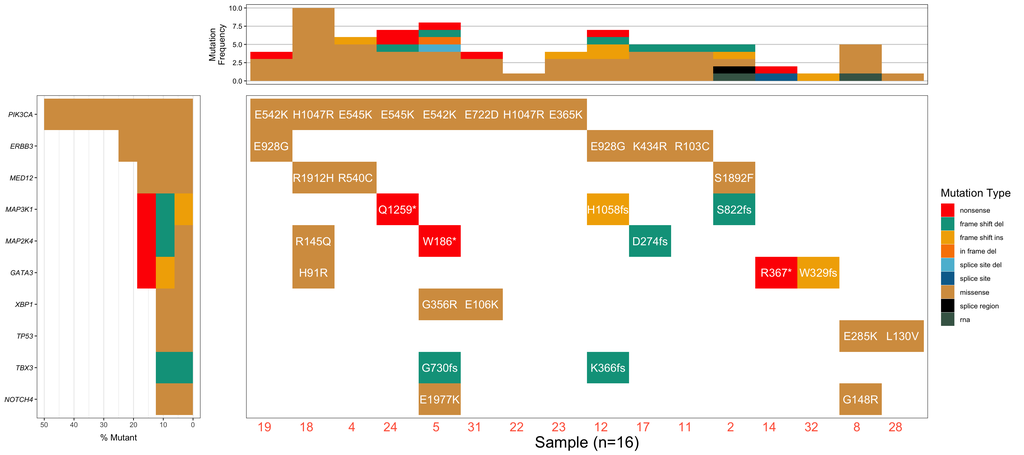

```r
drawPlot(plotData)
```